# Impact of season day and location of *P. pyralis* body metrics

2024-05-22

**Overview**

This file contains the code used to analyze firefly physiology data obtained in Summer 2022 from collections at three sites near Lewisburg. It examines the relationship between time in the season and location with each of the following metrics: + mass + elytral length + pronotum lenght + abdomen width + abdomen length + body condition (mass/elytral length)

## Step 1: Ready the workspace

```r
# #clear all inputs
# rm(list = ls())
#
# #Check for necessary packages
# list.of.packages <- c("ggplot2",
#                       "tidyr",
#                       "dplyr",
#                       "Hmisc",
#                       "qqplotr",
#                       "ggthemes",
#                       "fabricatr",
#                       "gridExtra",
#                       "grid",
#                       "kableExtra",
#                       "sjPlot",
#                       "cowplot",
#                       "ggpubr",
#                       "patchwork",
#                       "magick", #so you can use the savekable function
#                       "webshot", #so you can use the savekable function
#                       "lme4",
#                       "RcppEigen")
#
# #should install packages that you don't have
# new.packages <- list.of.packages[!(list.of.packages %in% installed.packages()[,"Package"])]
# if(length(new.packages)) install.packages(new.packages)
#Load the necessary packages
library(ggplot2)
library(tidyr)
library(dplyr)
library(Hmisc)
library(qqplotr)
library(ggthemes)
library(fabricatr)
library(gridExtra)
library(grid)
library(kableExtra)
library(sjPlot)
library(cowplot)
library(ggpubr)
library(patchwork)
library(car)
```

## Step 2: Import the data & calculate physiological condition

```r
#This imports the data from a CSV file and creates the data frame PrTC
Adult_Final<-read.table("FireflyData_ConservationPhys.csv", header=TRUE, sep=",", dec=".",na.strings=".")

#This sets up the color palette using tableau20: https://jrnold.github.io/ggthemes/reference/tableau_color_pal.html
site_colors <- c("USA: Montour Co, Bucknell Natural Area" = "#4E79A7",
                 "USA: Union Co, Bucknell Ropes Course" = "#E15759",
                 "USA: Union Co, St. Mary's Park" = "#F28E2B")

#Calculate Body Condition
Adult_Final$BodyCondition<-(Adult_Final$Mass/Adult_Final$ElytralLength)
```

## Step 3: Are the distributions within each **Location** and **SeasonDay** normal?

**Overall Conclusion**

- When doing a shapiro test on each collection individually, we rejected the null hypothesis that the body metrics are normally distributed on these days:
  - **Mass**: season day 15, 29, 32,44 and 45
  - **Elytral Length**: season day 38
  - **Pronotum Length**: none
  - **Abdomen Length**: season day 15, 17, 22, 36, 44
  - **Abdomen Width**: season day 24, 38
  - **Physiological Condition** season Day 15, 32 and 44
- However, after visual inspection of the qqplots we decided to proceed with LOESS modeling.

### Mass

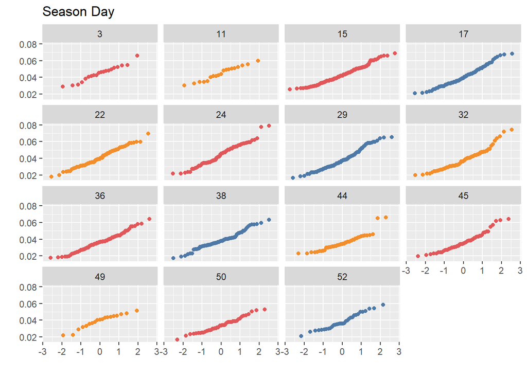

```r
#qq plots to assess normality
qplot(sample=Mass, data=Adult_Final, color=Location) +
  ggtitle("Season Day") +
  facet_wrap(~SeasonDay) +
  scale_color_manual(name = "Location", labels = c("BNA", "FDBCC", "StM"), values = c("#4E79A7", "#E15759", "#F28E2B")) +
  theme(legend.position = "none")
```

```r
#statistical test
shapiro.table <- NULL
for (day in levels(factor(Adult_Final$SeasonDay))){
  #subset table
  table.sub <- Adult_Final[Adult_Final$SeasonDay == day,]
  test.result <- (shapiro.test(table.sub$Mass))
  info <- data.frame(SeasonDay = day,
                     W = round(test.result[1]$statistic, 2), p = round(test.result[2]$p.value, 2))
  shapiro.table <- rbind(shapiro.table, info)
}

shapiro.table
```

```
##     SeasonDay    W    p
## W           3 0.97 0.75
## W1         11 0.96 0.63
## W2         15 0.98 0.01
## W3         17 0.97 0.05
## W4         22 0.99 0.54
## W5         24 0.98 0.10
## W6         29 0.97 0.01
## W7         32 0.94 0.00
## W8         36 0.98 0.24
## W9         38 0.97 0.06
## W10        44 0.89 0.00
## W11        45 0.95 0.02
## W12        49 0.94 0.27
## W13        50 0.97 0.38
## W14        52 0.97 0.40
```

### Elytral length

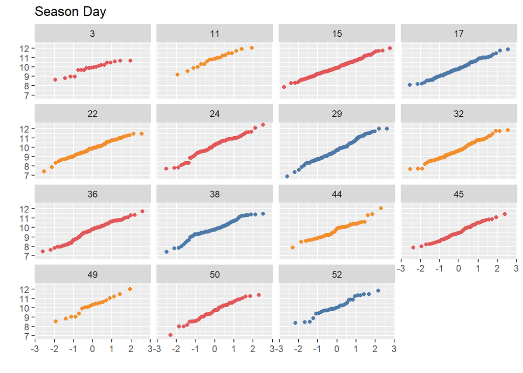

```r
#qq plots to assess normality
qplot(sample=ElytralLength, data=Adult_Final, color=Location) +
  ggtitle("Season Day") +
  facet_wrap(~SeasonDay) +
  scale_color_manual(name = "Location", labels = c("BNA", "FDBCC", "StM"), values = c("#4E79A7", "#E15759", "#F28E2B")) +
  theme(legend.position = "none")
```

```r
#statistical test
shapiro.table <- NULL
for (day in levels(factor(Adult_Final$SeasonDay))){
  #subset table
  table.sub <- Adult_Final[Adult_Final$SeasonDay == day,]
  test.result <- (shapiro.test(table.sub$ElytralLength))
  info <- data.frame(SeasonDay = day,
                     W = round(test.result[1]$statistic, 2), p = round(test.result[2]$p.value, 2))
  shapiro.table <- rbind(shapiro.table, info)
}

shapiro.table
```

```
##     SeasonDay    W    p
## W           3 0.92 0.10
## W1         11 0.98 0.91
## W2         15 1.00 0.94
## W3         17 0.99 0.75
## W4         22 0.99 0.63
## W5         24 0.97 0.07
## W6         29 0.99 0.66
## W7         32 0.99 0.61
## W8         36 0.98 0.05
## W9         38 0.96 0.02
## W10        44 0.97 0.32
## W11        45 0.98 0.54
## W12        49 0.97 0.81
## W13        50 0.98 0.69
## W14        52 0.96 0.37
```

### Pronotum length

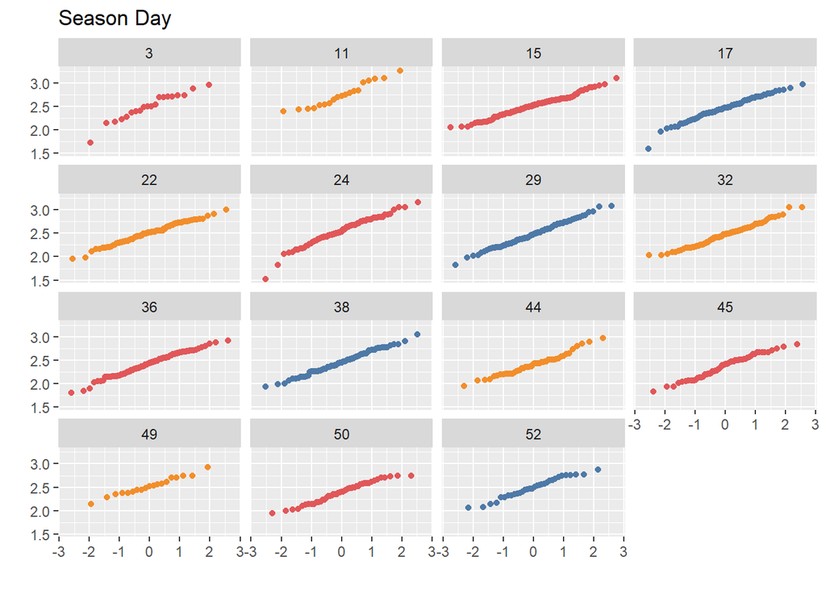

```r
#qq plots to assess normality
qplot(sample=PronotumLength, data=Adult_Final, color=Location) +
  ggtitle("Season Day") +
  facet_wrap(~SeasonDay) +
  scale_color_manual(name = "Location", labels = c("BNA", "FDBCC", "StM"), values = c("#4E79A7", "#E15759", "#F28E2B")) +
  theme(legend.position = "none")
```

```r
#statistical test
shapiro.table <- NULL
for (day in levels(factor(Adult_Final$SeasonDay))){
  #subset table
  table.sub <- Adult_Final[Adult_Final$SeasonDay == day,]
  test.result <- (shapiro.test(table.sub$PronotumLength))
  info <- data.frame(SeasonDay = day,
                     W = round(test.result[1]$statistic, 2), p = round(test.result[2]$p.value, 2))
  shapiro.table <- rbind(shapiro.table, info)
}

shapiro.table
```

```
##     SeasonDay    W    p
## W           3 0.95 0.38
## W1         11 0.94 0.29
## W2         15 0.99 0.17
## W3         17 0.98 0.16
## W4         22 0.99 0.81
## W5         24 0.97 0.06
## W6         29 0.99 0.96
## W7         32 0.99 0.40
## W8         36 0.99 0.48
## W9         38 0.99 0.92
## W10        44 0.97 0.40
## W11        45 0.98 0.29
## W12        49 0.99 0.99
## W13        50 0.97 0.26
## W14        52 0.97 0.47
```

### Abdomen length

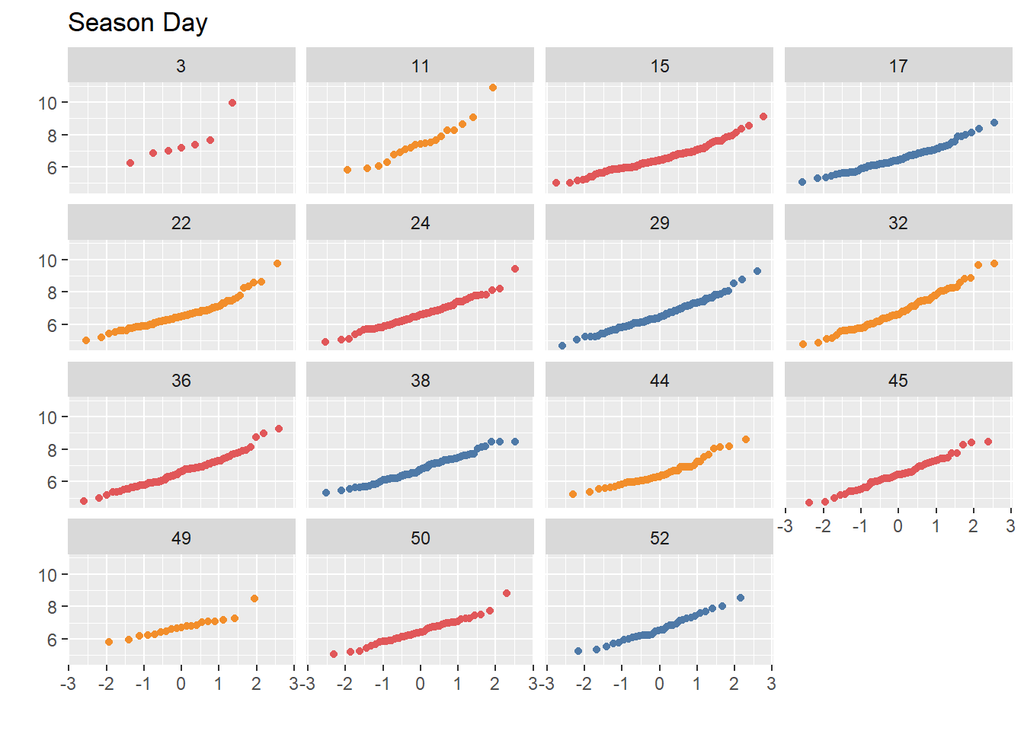

```r
#qq plots to assess normality
qplot(sample=AbdomenLength, data=Adult_Final, color=Location) +
  ggtitle("Season Day") +
  facet_wrap(~SeasonDay) +
  scale_color_manual(name = "Location", labels = c("BNA", "FDBCC", "StM"), values = c("#4E79A7", "#E15759", "#F28E2B")) +
  theme(legend.position = "none")
```

```r
#statistical test
shapiro.table <- NULL
for (day in levels(factor(Adult_Final$SeasonDay))){
  #subset table
  table.sub <- Adult_Final[Adult_Final$SeasonDay == day,]
  test.result <- (shapiro.test(table.sub$AbdomenLength))
  info <- data.frame(SeasonDay = day,
                     W = round(test.result[1]$statistic, 2), p = round(test.result[2]$p.value, 2))
  shapiro.table <- rbind(shapiro.table, info)
}

shapiro.table
```

```
##     SeasonDay    W    p
## W           3 0.81 0.05
## W1         11 0.92 0.14
## W2         15 0.97 0.00
## W3         17 0.97 0.04
## W4         22 0.93 0.00
## W5         24 0.98 0.13
## W6         29 0.98 0.10
## W7         32 0.98 0.11
## W8         36 0.97 0.04
## W9         38 0.98 0.22
## W10        44 0.94 0.01
## W11        45 0.98 0.65
## W12        49 0.91 0.07
## W13        50 0.98 0.41
## W14        52 0.98 0.77
```

### Abdomen Width

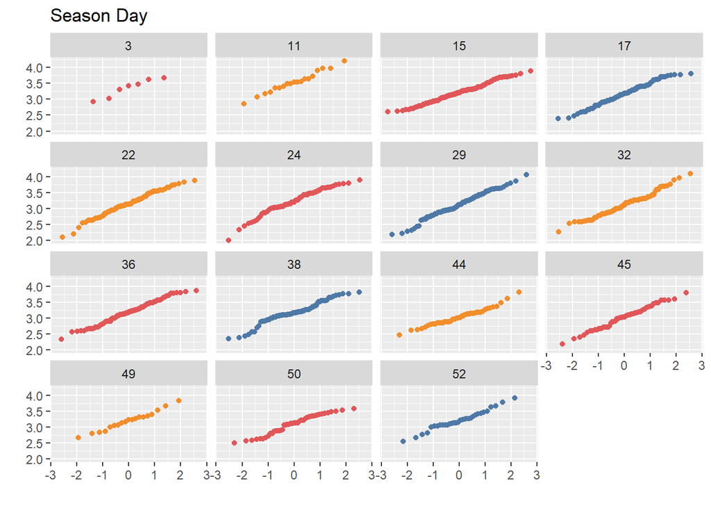

```r
#qq plots to assess normality
qplot(sample=AbdomenWidth, data=Adult_Final, color=Location) +
  ggtitle("Season Day") +
  facet_wrap(~SeasonDay) +
  scale_color_manual(name = "Location", labels = c("BNA", "FDBCC", "StM"), values = c("#4E79A7", "#E15759", "#F28E2B")) +
  theme(legend.position = "none")
```

```r
#statistical test
shapiro.table <- NULL
for (day in levels(factor(Adult_Final$SeasonDay))){
  #subset table
  table.sub <- Adult_Final[Adult_Final$SeasonDay == day,]
  test.result <- (shapiro.test(table.sub$AbdomenWidth))
  info <- data.frame(SeasonDay = day,
                     W = round(test.result[1]$statistic, 2), p = round(test.result[2]$p.value, 2))
  shapiro.table <- rbind(shapiro.table, info)
}

shapiro.table
```

```
##     SeasonDay    W    p
## W           3 0.92 0.51
## W1         11 0.99 0.99
## W2         15 0.99 0.34
## W3         17 0.99 0.37
## W4         22 0.99 0.39
## W5         24 0.97 0.02
## W6         29 0.99 0.48
## W7         32 0.98 0.22
## W8         36 0.99 0.49
## W9         38 0.95 0.00
## W10        44 0.98 0.42
## W11        45 0.99 0.88
## W12        49 0.98 0.98
## W13        50 0.95 0.05
## W14        52 0.98 0.74
```

### Body Condition

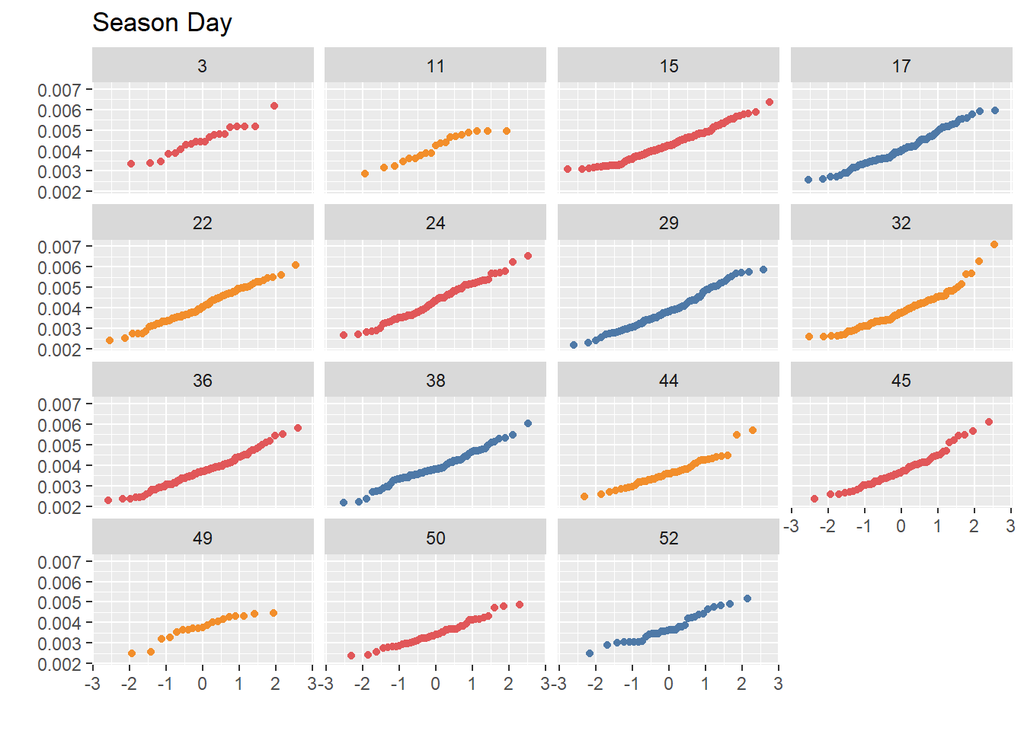

```r
#qq plots to assess normality
qplot(sample=BodyCondition, data=Adult_Final, color=Location) +
  ggtitle("Season Day") +
  facet_wrap(~SeasonDay) +
  scale_color_manual(name = "Location", labels = c("BNA", "FDBCC", "StM"), values = c("#4E79A7", "#E15759", "#F28E2B")) +
  theme(legend.position = "none")
```

```r
#statistical test
shapiro.table <- NULL
for (day in levels(factor(Adult_Final$SeasonDay))){
  #subset table
  table.sub <- Adult_Final[Adult_Final$SeasonDay == day,]
  test.result <- (shapiro.test(table.sub$BodyCondition))
  info <- data.frame(SeasonDay = day,
                     W = round(test.result[1]$statistic, 2), p = round(test.result[2]$p.value, 2))
  shapiro.table <- rbind(shapiro.table, info)
}

shapiro.table
```

```
##     SeasonDay    W    p
## W           3 0.96 0.53
## W1         11 0.92 0.14
## W2         15 0.98 0.03
## W3         17 0.98 0.11
## W4         22 0.99 0.70
## W5         24 0.99 0.47
## W6         29 0.98 0.09
## W7         32 0.94 0.00
## W8         36 0.98 0.22
## W9         38 0.98 0.34
## W10        44 0.95 0.03
## W11        45 0.96 0.06
## W12        49 0.91 0.08
## W13        50 0.97 0.40
## W14        52 0.96 0.23
```

## Step 4: Are metrics correlated?

- All metrics were positively correlated, but some had stronger correlation than others
- Decided to proceed with analysis of each metric separately

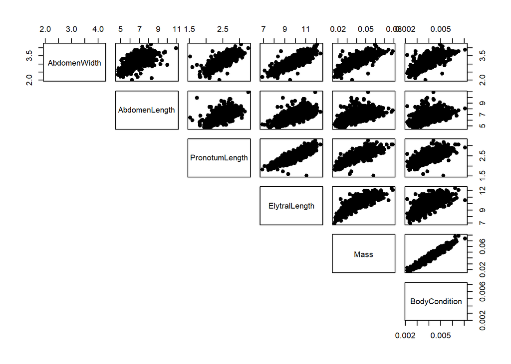

```r
pairs(Adult_Final[,7:12],pch = 19,lower.panel = NULL)
```

```r
cor(Adult_Final[,7:12],use="complete.obs")
```

```
##                AbdomenWidth AbdomenLength PronotumLength ElytralLength
## AbdomenWidth      1.0000000     0.5853697      0.7773514     0.8368927
## AbdomenLength     0.5853697     1.0000000      0.5715650     0.6455222
## PronotumLength    0.7773514     0.5715650      1.0000000     0.8315468
## ElytralLength     0.8368927     0.6455222      0.8315468     1.0000000
## Mass              0.8246945     0.5243849      0.7864758     0.8401022
## BodyCondition     0.7501417     0.4268929      0.6994165     0.6976806
##                     Mass BodyCondition
## AbdomenWidth   0.8246945     0.7501417
## AbdomenLength  0.5243849     0.4268929
## PronotumLength 0.7864758     0.6994165
## ElytralLength  0.8401022     0.6976806
## Mass           1.0000000     0.9710522
## BodyCondition  0.9710522     1.0000000
```

## Step 5: Determine how season day and location affects physiology

**Overall Conclusion**

- Based on LOESS models, all size metrics had a non-linear relationship with season day for at least one location, rendering linear modeling not appropriate.
- For body condition, examination of the LOESS model revealed a relatively linear relationship across season day at all locations, and so we proceeded with linear modeling to allow us to statistically assess differences in the relationship across the three sites.

### Mass

**Summary Table of Means by Location**

```r
#generate tibble
t<- Adult_Final %>%
  group_by(Location) %>%
  summarise(N=n(), mean_length=round(mean(Mass),3), SD = round(sd(Mass), 3))

#generate nice looking table
kbl(t, col.names = c("Location", "n", "Mean mass (g)", "SD"), align = "lccc") %>%
  kable_classic(full_width = F, html_font = "Cambria")
```

| Location | n | Mean mass (g) | SD |
| --- | --- | --- | --- |
| USA: Montour Co, Bucknell Natural Area | 318 | 0.039 | 0.011 |
| USA: Union Co, Bucknell Ropes Course | 490 | 0.040 | 0.011 |
| USA: Union Co, St. Mary’s Park | 267 | 0.039 | 0.010 |

#### SeasonDay x Location LOESS

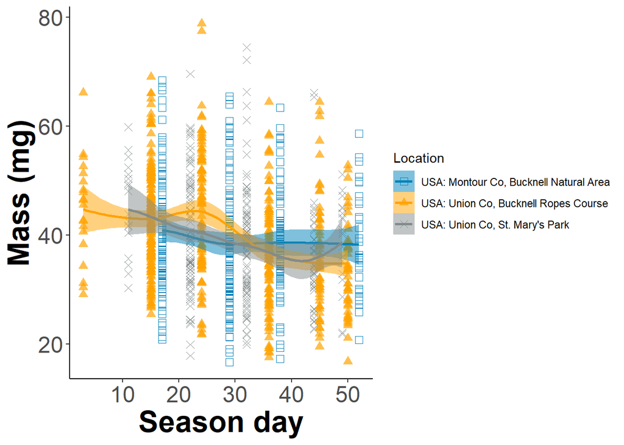

```r
#png(file="Figure2A_mass.png", width = 3200, height = 1600, res=300)

ggplot(Adult_Final, aes(x=SeasonDay, y=Mass*1000,shape=Location, color=Location,alpha=Location)) +
  geom_point(aes(shape=Location, color=Location), size=2.5)+  scale_shape_manual(values=c(0, 17, 4))+
  scale_color_manual(values=c("#0082BA","#FFA300","#838B8B"))+
  scale_alpha_manual(values=c(1,.7,1))+
  theme(legend.position="top")+ theme(plot.margin = unit(c(1, 2, 1, 2), "inches"))+
 geom_smooth(se = TRUE, method=loess, aes(fill=Location, ), alpha = .5, size = 0, lwd=1) + theme_bw()+ theme_classic() +
  xlab("Season day") + ylab("Mass (mg)") + scale_fill_manual(values=c("#0082BA","#FFA300","#838B8B"))+
theme(axis.title.x = element_text(size=24, face="bold"),
axis.title.y = element_text(size=24, face="bold")) + theme(axis.text = element_text(size = 18))
```

```r
#dev.off ()
```

#### Other visualizations

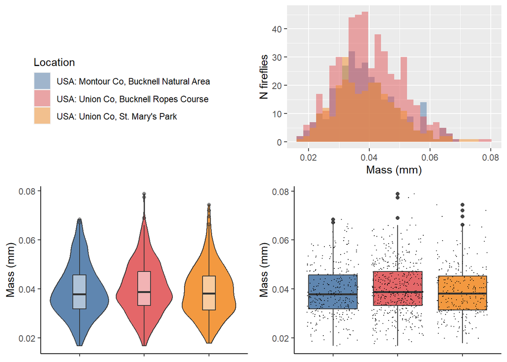

```r
#generate labels for sites that include sample size
site_labels = c(paste("BNA", " (n = ", t$N[1], ")", sep=""),
                paste0("FDBCC", " (n = ", t$N[2], ")"),
                paste0("StM",  " (n = ", t$N[3], ")"))

#generate text placeholder
a <- ggplot(Adult_Final, aes(x=Mass, fill=Location,)) +
  geom_histogram(alpha= 0.5, position="identity") +
  scale_fill_manual(name = "Location",
                    #labels = site_labels,
                    values = site_colors)

legend.a <- cowplot::get_legend(a)

#generate histogram
b <- ggplot(Adult_Final, aes(x=Mass, fill=Location)) +
  geom_histogram(alpha= 0.5, position="identity") +
  xlab("Mass (mm)") +
  ylab("N fireflies") +
  theme(plot.title = element_text(hjust = 0.5), legend.position = "none") +
  scale_fill_manual(name = "Location", labels = site_labels, values = site_colors)+
  scale_fill_manual(name = "Location", labels = c("BNA", "FDBCC", "StM"), values = c("#4E79A7", "#E15759", "#F28E2B"))

#generate violin plot
c <- ggplot(Adult_Final, aes(x=Location, y=Mass, fill=Location,)) +
  geom_violin(alpha = 0.9) +
  theme_classic() +
  ylab("Mass (mm)") +
  theme(plot.title = element_text(hjust = 0.5), legend.position = "none", axis.text.x=element_blank(), axis.title.x=element_blank()) +
  geom_boxplot(width=0.2, alpha= 0.5, fill = "white") +
  scale_fill_manual(values = site_colors) +
  scale_fill_manual(name = "Location", labels = c("BNA", "FDBCC", "StM"), values = c("#4E79A7", "#E15759", "#F28E2B"))

#generate boxplot
d <- ggplot(Adult_Final, aes(x=Location, y=Mass, fill=Location,)) +
  geom_boxplot(alpha = 0.9) +
  geom_jitter(size = 0.1)+
  theme_classic() +
  ylab("Mass (mm)") +
  theme(plot.title = element_text(hjust = 0.5), legend.position = "none", axis.text.x=element_blank(), axis.title.x=element_blank()) +
  scale_fill_manual(values = site_colors) +
  scale_fill_manual(name = "Location", labels = c("BNA", "FDBCC", "StM"), values = c("#4E79A7", "#E15759", "#F28E2B"))

grid.arrange(legend.a,b,c,d, nrow=2)
```

### Elytral Length

**Summary Table**

```r
#generate tibble
t<- Adult_Final %>%
  group_by(Location) %>%
  summarise(N=n(), mean_length=round(mean(ElytralLength),2), SD = round(sd(ElytralLength), 2))

#generate nice looking table
kbl(t, col.names = c("Location", "n", "Mean elytron length (mm)", "SD"), align = "lccc") %>%
  kable_classic(full_width = F, html_font = "Cambria")
```

| Location | n | Mean elytron length (mm) | SD |
| --- | --- | --- | --- |
| USA: Montour Co, Bucknell Natural Area | 318 | 9.83 | 0.92 |
| USA: Union Co, Bucknell Ropes Course | 490 | 9.84 | 0.88 |
| USA: Union Co, St. Mary’s Park | 267 | 9.88 | 0.90 |

#### SeasonDay x Location LOESS

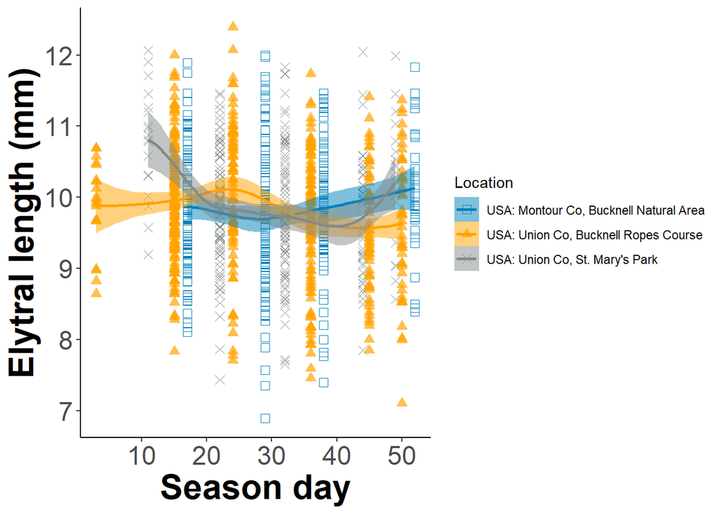

```r
#png(file="Figure1B_ElytralLength.png", width = 3200, height = 1600, res=300)


ggplot(Adult_Final, aes(x=SeasonDay, y=ElytralLength,shape=Location, color=Location,alpha=Location)) +
  geom_point(aes(shape=Location, color=Location), size=2.5)+  scale_shape_manual(values=c(0, 17, 4))+
  scale_color_manual(values=c("#0082BA","#FFA300","#838B8B"))+
  scale_alpha_manual(values=c(1,.7,1))+
  theme(legend.position="top")+ theme(plot.margin = unit(c(1, 2, 1, 2), "inches"))+
 geom_smooth(se = TRUE, method=loess, aes(fill=Location, ), alpha = .5, size = 0,lwd=1) + theme_bw()+ theme_classic() +
  xlab("Season day") + ylab("Elytral length (mm)") + scale_fill_manual(values=c("#0082BA","#FFA300","#838B8B"))+
theme(axis.title.x = element_text(size=24, face="bold"),
axis.title.y = element_text(size=24, face="bold")) + theme(axis.text = element_text(size = 18))
```

```r
#dev.off ()
```

#### Other visualizations

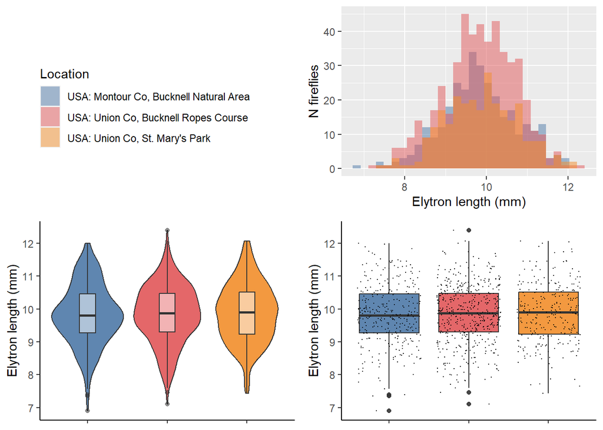

```r
#generate labels for sites that include sample size
site_labels = c(paste("BNA", " (n = ", t$N[1], ")", sep=""),
                paste0("FDBCC", " (n = ", t$N[2], ")"),
                paste0("StM",  " (n = ", t$N[3], ")"))

#generate text placeholder
a <- ggplot(Adult_Final, aes(x=ElytralLength, fill=Location,)) +
  geom_histogram(alpha= 0.5, position="identity") +
  scale_fill_manual(name = "Location",
                    #labels = site_labels,
                    values = site_colors)

legend.a <- cowplot::get_legend(a)

#generate histogram
b <- ggplot(Adult_Final, aes(x=ElytralLength, fill=Location)) +
  geom_histogram(alpha= 0.5, position="identity") +
  xlab("Elytron length (mm)") +
  ylab("N fireflies") +
  theme(plot.title = element_text(hjust = 0.5), legend.position = "none") +
  scale_fill_manual(name = "Location", labels = site_labels, values = site_colors)+
  scale_fill_manual(name = "Location", labels = c("BNA", "FDBCC", "StM"), values = c("#4E79A7", "#E15759", "#F28E2B"))

#generate violin plot
c <- ggplot(Adult_Final, aes(x=Location, y=ElytralLength, fill=Location,)) +
  geom_violin(alpha = 0.9) +
  theme_classic() +
  ylab("Elytron length (mm)") +
  theme(plot.title = element_text(hjust = 0.5), legend.position = "none", axis.text.x=element_blank(), axis.title.x=element_blank()) +
  geom_boxplot(width=0.2, alpha= 0.5, fill = "white") +
  scale_fill_manual(values = site_colors) +
  scale_fill_manual(name = "Location", labels = c("BNA", "FDBCC", "StM"), values = c("#4E79A7", "#E15759", "#F28E2B"))

#generate boxplot
d <- ggplot(Adult_Final, aes(x=Location, y=ElytralLength, fill=Location,)) +
  geom_boxplot(alpha = 0.9) +
  geom_jitter(size = 0.1)+
  theme_classic() +
  ylab("Elytron length (mm)") +
  theme(plot.title = element_text(hjust = 0.5), legend.position = "none", axis.text.x=element_blank(), axis.title.x=element_blank()) +
  scale_fill_manual(values = site_colors) +
  scale_fill_manual(name = "Location", labels = c("BNA", "FDBCC", "StM"), values = c("#4E79A7", "#E15759", "#F28E2B"))

grid.arrange(legend.a,b,c,d, nrow=2)
```

### Pronotum Length

**Summary Table**

```r
#generate tibble
t<- Adult_Final %>%
  group_by(Location) %>%
  summarise(N=n(), mean_length=round(mean(PronotumLength),2), SD = round(sd(PronotumLength), 2))

#generate nice looking table
kbl(t, col.names = c("Location", "n", "Mean pronotum length (mm)", "SD"), align = "lccc") %>%
  kable_classic(full_width = F, html_font = "Cambria")
```

| Location | n | Mean pronotum length (mm) | SD |
| --- | --- | --- | --- |
| USA: Montour Co, Bucknell Natural Area | 318 | 2.47 | 0.23 |
| USA: Union Co, Bucknell Ropes Course | 490 | 2.47 | 0.24 |
| USA: Union Co, St. Mary’s Park | 267 | 2.49 | 0.23 |

#### SeasonDay x Location LOESS

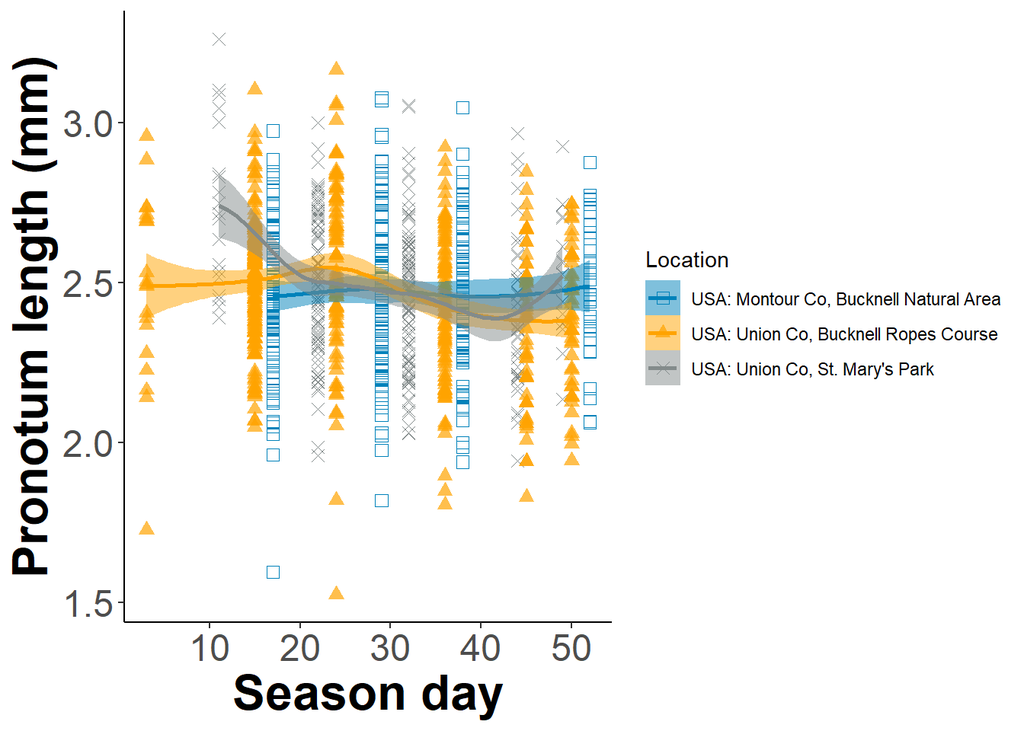

```r
#png(file="SFig2C_Pronotum.png", width = 3200, height = 1600, res=300)

ggplot(Adult_Final, aes(x=SeasonDay, y=PronotumLength,shape=Location, color=Location,alpha=Location)) +
  geom_point(aes(shape=Location, color=Location), size=2.5)+  scale_shape_manual(values=c(0, 17, 4))+
  scale_color_manual(values=c("#0082BA","#FFA300","#838B8B"))+
  scale_alpha_manual(values=c(1,.7,1))+
  theme(legend.position="top")+ theme(plot.margin = unit(c(1, 2, 1, 2), "inches"))+
 geom_smooth(se = TRUE, method=loess, aes(fill=Location, ), alpha = .5, size = 0, lwd=1) + theme_bw()+ theme_classic() +
  xlab("Season day") + ylab("Pronotum length (mm)") + scale_fill_manual(values=c("#0082BA","#FFA300","#838B8B"))+
theme(axis.title.x = element_text(size=24, face="bold"),
axis.title.y = element_text(size=24, face="bold")) + theme(axis.text = element_text(size = 18))
```

```r
#dev.off()
```

#### Other visualizations

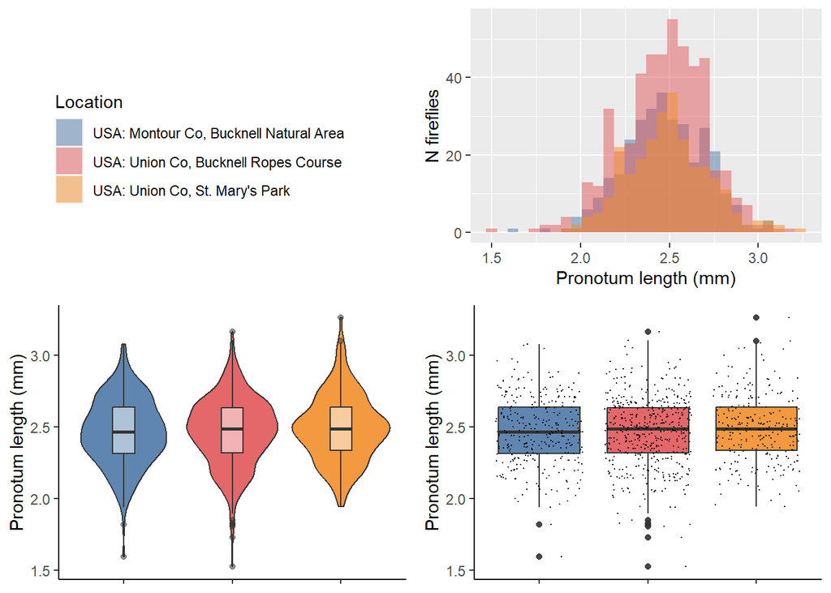

```r
#generate labels for sites that include sample size
site_labels = c(paste("BNA", " (n = ", t$N[1], ")", sep=""),
                paste0("FDBCC", " (n = ", t$N[2], ")"),
                paste0("StM",  " (n = ", t$N[3], ")"))

#generate text placeholder
a <- ggplot(Adult_Final, aes(x=PronotumLength, fill=Location,)) +
  geom_histogram(alpha= 0.5, position="identity") +
  scale_fill_manual(name = "Location",
                    #labels = site_labels,
                    values = site_colors)

legend.a <- cowplot::get_legend(a)

#generate histogram
b <- ggplot(Adult_Final, aes(x=PronotumLength, fill=Location)) +
  geom_histogram(alpha= 0.5, position="identity") +
  xlab("Pronotum length (mm)") +
  ylab("N fireflies") +
  theme(plot.title = element_text(hjust = 0.5), legend.position = "none") +
  scale_fill_manual(name = "Location", labels = site_labels, values = site_colors)+
  scale_fill_manual(name = "Location", labels = c("BNA", "FDBCC", "StM"), values = c("#4E79A7", "#E15759", "#F28E2B"))

#generate violin plot
c <- ggplot(Adult_Final, aes(x=Location, y=PronotumLength, fill=Location,)) +
  geom_violin(alpha = 0.9) +
  theme_classic() +
  ylab("Pronotum length (mm)") +
  theme(plot.title = element_text(hjust = 0.5), legend.position = "none", axis.text.x=element_blank(), axis.title.x=element_blank()) +
  geom_boxplot(width=0.2, alpha= 0.5, fill = "white") +
  scale_fill_manual(values = site_colors) +
  scale_fill_manual(name = "Location", labels = c("BNA", "FDBCC", "StM"), values = c("#4E79A7", "#E15759", "#F28E2B"))

#generate boxplot
d <- ggplot(Adult_Final, aes(x=Location, y=PronotumLength, fill=Location,)) +
  geom_boxplot(alpha = 0.9) +
  geom_jitter(size = 0.1)+
  theme_classic() +
  ylab("Pronotum length (mm)") +
  theme(plot.title = element_text(hjust = 0.5), legend.position = "none", axis.text.x=element_blank(), axis.title.x=element_blank()) +
  scale_fill_manual(values = site_colors) +
  scale_fill_manual(name = "Location", labels = c("BNA", "FDBCC", "StM"), values = c("#4E79A7", "#E15759", "#F28E2B"))

grid.arrange(legend.a,b,c,d, nrow=2)
```

### Abdomen Length

**Summary Table**

```r
#generate tibble
t<- Adult_Final %>%
  group_by(Location) %>%
  summarise(N=n(), mean_length=round(mean(AbdomenLength, na.rm = TRUE),2), SD = round(sd(AbdomenLength, na.rm = TRUE), 2))


#generate nice looking table
kbl(t, col.names = c("Location", "n", "Mean abdomen length (mm)", "SD"), align = "lccc") %>%
  kable_classic(full_width = F, html_font = "Cambria")
```

| Location | n | Mean abdomen length (mm) | SD |
| --- | --- | --- | --- |
| USA: Montour Co, Bucknell Natural Area | 318 | 6.61 | 0.76 |
| USA: Union Co, Bucknell Ropes Course | 490 | 6.54 | 0.76 |
| USA: Union Co, St. Mary’s Park | 267 | 6.71 | 0.91 |

#### SeasonDay x Location LOESS

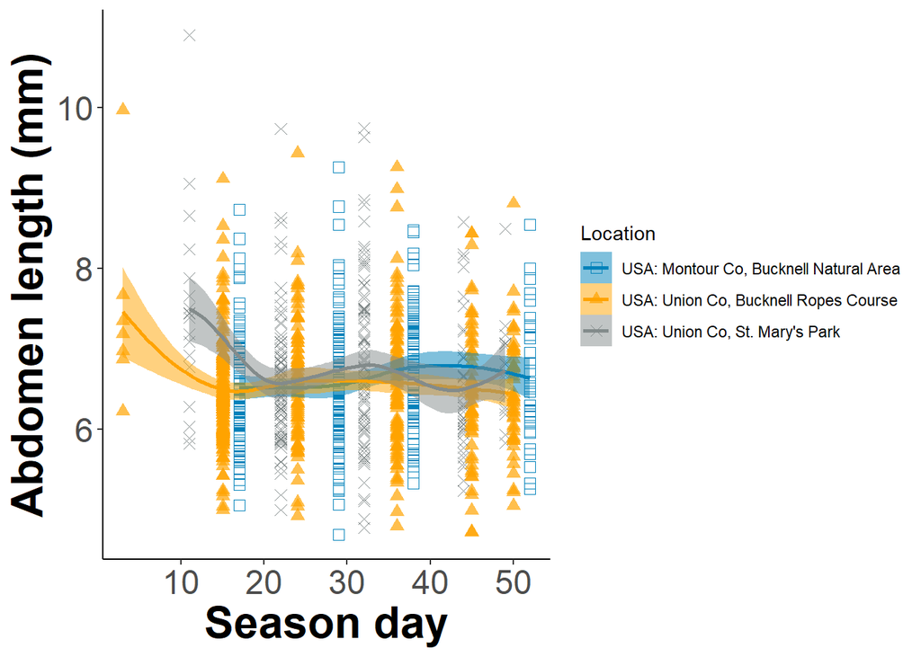

```r
#png(file="SFigA_AbdomenLength.png", width = 3200, height = 1600, res=300)
ggplot(Adult_Final, aes(x=SeasonDay, y=AbdomenLength,shape=Location, color=Location,alpha=Location)) +
  geom_point(aes(shape=Location, color=Location), size=2.5)+  scale_shape_manual(values=c(0, 17, 4))+
  scale_color_manual(values=c("#0082BA","#FFA300","#838B8B"))+
  scale_alpha_manual(values=c(1,.7,1))+
  theme(legend.position="top")+ theme(plot.margin = unit(c(1, 2, 1, 2), "inches"))+
 geom_smooth(se = TRUE, method=loess, aes(fill=Location, ), alpha = .5, size = 0,lwd=1) + theme_bw()+ theme_classic() +
  xlab("Season day") + ylab("Abdomen length (mm)") + scale_fill_manual(values=c("#0082BA","#FFA300","#838B8B"))+
theme(axis.title.x = element_text(size=24, face="bold"),
axis.title.y = element_text(size=24, face="bold")) + theme(axis.text = element_text(size = 18))
```

```r
#dev.off()
```

#### Other visualizations

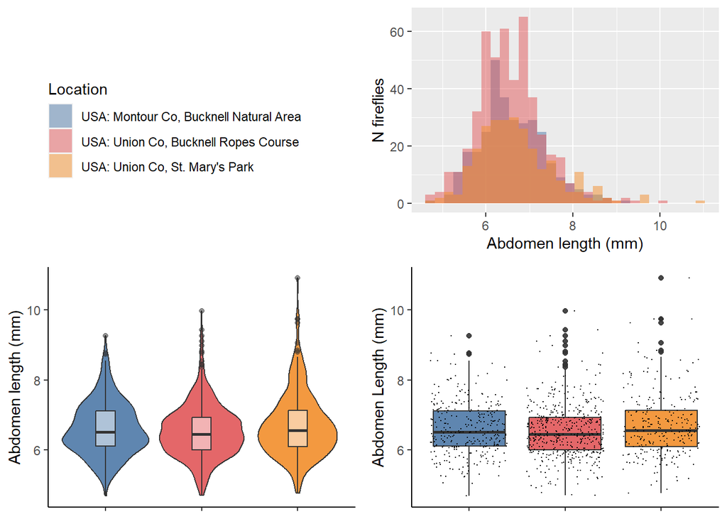

```r
#generate labels for sites that include sample size
site_labels = c(paste("BNA", " (n = ", t$N[1], ")", sep=""),
                paste0("FDBCC", " (n = ", t$N[2], ")"),
                paste0("StM",  " (n = ", t$N[3], ")"))

#generate text placeholder
a <- ggplot(Adult_Final, aes(x=AbdomenLength, fill=Location,)) +
  geom_histogram(alpha= 0.5, position="identity") +
  scale_fill_manual(name = "Location",
                    #labels = site_labels,
                    values = site_colors)

legend.a <- cowplot::get_legend(a)
#generate histogram
b <- ggplot(Adult_Final, aes(x=AbdomenLength, fill=Location)) +
  geom_histogram(alpha= 0.5, position="identity") +
  xlab("Abdomen length (mm)") +
  ylab("N fireflies") +
  theme(plot.title = element_text(hjust = 0.5), legend.position = "none") +
  scale_fill_manual(name = "Location", labels = site_labels, values = site_colors)+
  scale_fill_manual(name = "Location", labels = c("BNA", "FDBCC", "StM"), values = c("#4E79A7", "#E15759", "#F28E2B"))

#generate violin plot
c <- ggplot(Adult_Final, aes(x=Location, y=AbdomenLength, fill=Location,)) +
  geom_violin(alpha = 0.9) +
  theme_classic() +
  ylab("Abdomen length (mm)") +
  theme(plot.title = element_text(hjust = 0.5), legend.position = "none", axis.text.x=element_blank(), axis.title.x=element_blank()) +
  geom_boxplot(width=0.2, alpha= 0.5, fill = "white") +
  scale_fill_manual(values = site_colors) +
  scale_fill_manual(name = "Location", labels = c("BNA", "FDBCC", "StM"), values = c("#4E79A7", "#E15759", "#F28E2B"))

#generate boxplot
d <- ggplot(Adult_Final, aes(x=Location, y=AbdomenLength, fill=Location,)) +
  geom_boxplot(alpha = 0.9) +
  geom_jitter(size = 0.1)+
  theme_classic() +
  ylab("Abdomen Length (mm)") +
  theme(plot.title = element_text(hjust = 0.5), legend.position = "none", axis.text.x=element_blank(), axis.title.x=element_blank()) +
  scale_fill_manual(values = site_colors) +
  scale_fill_manual(name = "Location", labels = c("BNA", "FDBCC", "StM"), values = c("#4E79A7", "#E15759", "#F28E2B"))

grid.arrange(legend.a,b,c,d, nrow=2)
```

### Abdomen Width

**Summary Table of Means**

```r
#generate tibble
t<- Adult_Final %>%
  group_by(Location) %>%
  summarise(N=n(), mean_length=round(mean(AbdomenWidth, na.rm = TRUE),2), SD = round(sd(AbdomenWidth, na.rm = TRUE), 2))

#generate nice looking table
kbl(t, col.names = c("Location", "n", "Mean abdomen width (mm)", "SD"), align = "lccc") %>%
  kable_classic(full_width = F, html_font = "Cambria")
```

| Location | n | Mean abdomen width (mm) | SD |
| --- | --- | --- | --- |
| USA: Montour Co, Bucknell Natural Area | 318 | 3.16 | 0.34 |
| USA: Union Co, Bucknell Ropes Course | 490 | 3.17 | 0.32 |
| USA: Union Co, St. Mary’s Park | 267 | 3.15 | 0.35 |

#### SeasonDay x Location LOESS

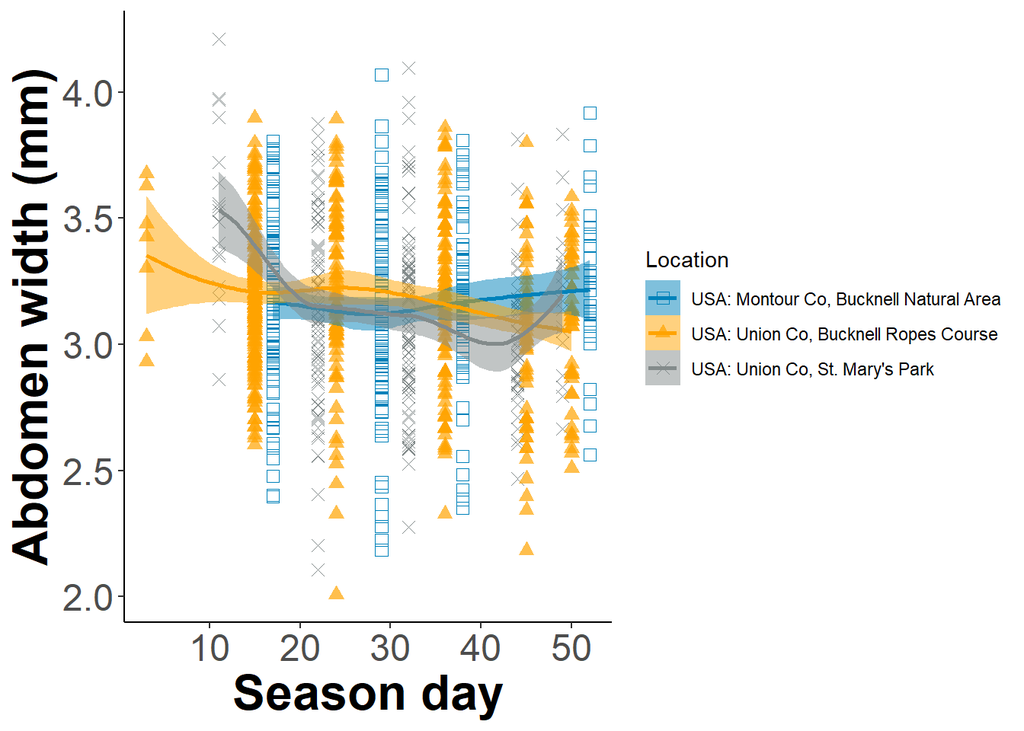

```r
#png(file="SFig2B_AbdomenWidth.png", width = 3200, height = 1600, res=300)

ggplot(Adult_Final, aes(x=SeasonDay, y=AbdomenWidth,shape=Location, color=Location,alpha=Location)) +
  geom_point(aes(shape=Location, color=Location), size=2.5)+  scale_shape_manual(values=c(0, 17, 4))+
  scale_color_manual(values=c("#0082BA","#FFA300","#838B8B"))+
  scale_alpha_manual(values=c(1,.7,1))+
  theme(legend.position="top")+ theme(plot.margin = unit(c(1, 2, 1, 2), "inches"))+
 geom_smooth(se = TRUE, method=loess, aes(fill=Location, ), alpha = .5, size = 0,lwd=1) + theme_bw()+ theme_classic() +
  xlab("Season day") + ylab("Abdomen width (mm)") + scale_fill_manual(values=c("#0082BA","#FFA300","#838B8B"))+
theme(axis.title.x = element_text(size=24, face="bold"),
axis.title.y = element_text(size=24, face="bold")) + theme(axis.text = element_text(size = 18))
```

```r
#dev.off()
```

#### Other visualizations

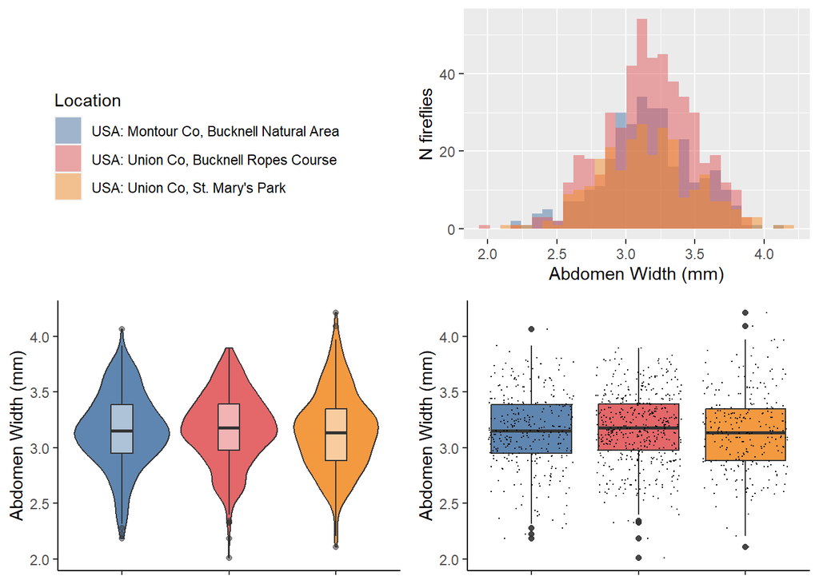

```r
#generate labels for sites that include sample size
site_labels = c(paste("BNA", " (n = ", t$N[1], ")", sep=""),
                paste0("FDBCC", " (n = ", t$N[2], ")"),
                paste0("StM",  " (n = ", t$N[3], ")"))

#generate text placeholder
a <- ggplot(Adult_Final, aes(x=AbdomenWidth, fill=Location,)) +
  geom_histogram(alpha= 0.5, position="identity") +
  scale_fill_manual(name = "Location",
                    #labels = site_labels,
                    values = site_colors)

legend.a <- cowplot::get_legend(a)
#generate histogram
b <- ggplot(Adult_Final, aes(x=AbdomenWidth, fill=Location)) +
  geom_histogram(alpha= 0.5, position="identity") +
  xlab("Abdomen Width (mm)") +
  ylab("N fireflies") +
  theme(plot.title = element_text(hjust = 0.5), legend.position = "none") +
  scale_fill_manual(name = "Location", labels = site_labels, values = site_colors)+
  scale_fill_manual(name = "Location", labels = c("BNA", "FDBCC", "StM"), values = c("#4E79A7", "#E15759", "#F28E2B"))

#generate violin plot
c <- ggplot(Adult_Final, aes(x=Location, y=AbdomenWidth, fill=Location,)) +
  geom_violin(alpha = 0.9) +
  theme_classic() +
  ylab("Abdomen Width (mm)") +
  theme(plot.title = element_text(hjust = 0.5), legend.position = "none", axis.text.x=element_blank(), axis.title.x=element_blank()) +
  geom_boxplot(width=0.2, alpha= 0.5, fill = "white") +
  scale_fill_manual(values = site_colors) +
  scale_fill_manual(name = "Location", labels = c("BNA", "FDBCC", "StM"), values = c("#4E79A7", "#E15759", "#F28E2B"))

#generate boxplot
d <- ggplot(Adult_Final, aes(x=Location, y=AbdomenWidth, fill=Location,)) +
  geom_boxplot(alpha = 0.9) +
  geom_jitter(size = 0.1)+
  theme_classic() +
  ylab("Abdomen Width (mm)") +
  theme(plot.title = element_text(hjust = 0.5), legend.position = "none", axis.text.x=element_blank(), axis.title.x=element_blank()) +
  scale_fill_manual(values = site_colors) +
  scale_fill_manual(name = "Location", labels = c("BNA", "FDBCC", "StM"), values = c("#4E79A7", "#E15759", "#F28E2B"))

grid.arrange(legend.a,b,c,d, nrow=2)
```

### Body condition

**Summary Table of Means by Location**

```r
#generate tibble
t<- Adult_Final %>%
  group_by(Location) %>%
  summarise(N=n(), mean_length=round(mean(BodyCondition*1000),2), SD = round(sd(BodyCondition*1000), 2))

#generate nice looking table
kbl(t, col.names = c("Location", "n", "Mean Body Condition (mg/mm)", "SD"), align = "lccc") %>%
  kable_classic(full_width = F, html_font = "Cambria")
```

| Location | n | Mean Body Condition (mg/mm) | SD |
| --- | --- | --- | --- |
| USA: Montour Co, Bucknell Natural Area | 318 | 3.93 | 0.77 |
| USA: Union Co, Bucknell Ropes Course | 490 | 4.04 | 0.79 |
| USA: Union Co, St. Mary’s Park | 267 | 3.91 | 0.76 |

#### SeasonDay x Location LOESS

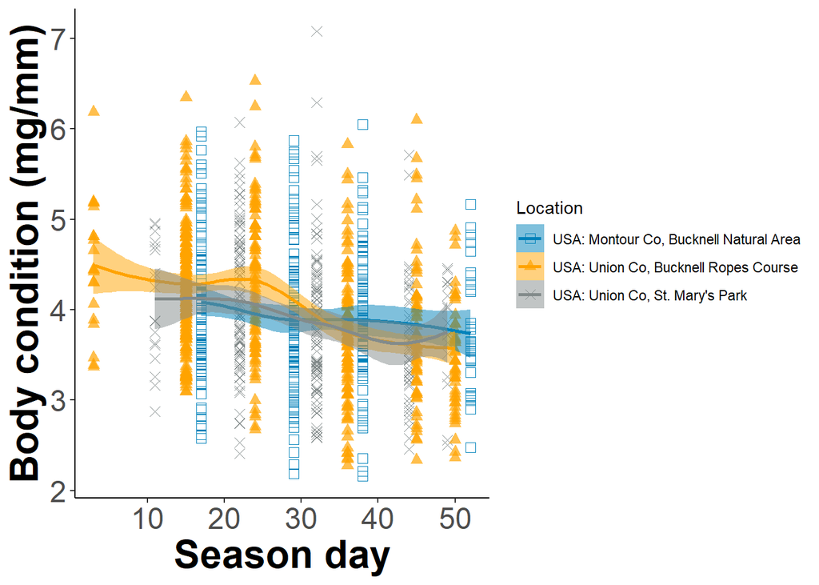

```r
#png(file="SFig2D_PhysCondition_loess.png", width = 3200, height = 1600, res=300)

ggplot(Adult_Final, aes(x=SeasonDay, y=BodyCondition*1000,shape=Location, color=Location,alpha=Location)) +
  geom_point(aes(shape=Location, color=Location), size=2.5)+  scale_shape_manual(values=c(0, 17, 4))+
  scale_color_manual(values=c("#0082BA","#FFA300","#838B8B"))+
  scale_alpha_manual(values=c(1,.7,1))+
  theme(legend.position="top")+ theme(plot.margin = unit(c(1, 2, 1, 2), "inches"))+
 geom_smooth(se = TRUE, method=loess, aes(fill=Location, ), alpha = .5, size = 0,lwd=1) + theme_bw()+ theme_classic() +
  xlab("Season day") + ylab("Body condition (mg/mm)") + scale_fill_manual(values=c("#0082BA","#FFA300","#838B8B"))+
theme(axis.title.x = element_text(size=24, face="bold"),
axis.title.y = element_text(size=24, face="bold")) + theme(axis.text = element_text(size = 18))
```

```r
#dev.off()
```

#### ANOVA

```r
lmBodyC <- lm(1000*BodyCondition~SeasonDay+Location+SeasonDay:Location, data = Adult_Final,contrasts=list(Location=contr.sum))
lm.to.print<-lmBodyC

summary(lmBodyC)
```

```
##
## Call:
## lm(formula = 1000 * BodyCondition ~ SeasonDay + Location + SeasonDay:Location,
##     data = Adult_Final, contrasts = list(Location = contr.sum))
##
## Residuals:
##     Min      1Q  Median      3Q     Max
## -1.7572 -0.5060 -0.0776  0.4887  3.1967
##
## Coefficients:
##                      Estimate Std. Error t value Pr(>|t|)
## (Intercept)          4.421357   0.067271  65.724  < 2e-16 ***
## SeasonDay           -0.015925   0.002111  -7.544 9.75e-14 ***
## Location1           -0.205199   0.098089  -2.092  0.03668 *
## Location2            0.232509   0.080453   2.890  0.00393 **
## SeasonDay:Location1  0.006477   0.003071   2.109  0.03516 *
## SeasonDay:Location2 -0.006489   0.002554  -2.540  0.01122 *
## ---
## Signif. codes:  0 '***' 0.001 '**' 0.01 '*' 0.05 '.' 0.1 ' ' 1
##
## Residual standard error: 0.7438 on 1069 degrees of freedom
## Multiple R-squared:  0.09075,    Adjusted R-squared:  0.08649
## F-statistic: 21.34 on 5 and 1069 DF,  p-value: < 2.2e-16
```

```r
Anova(lmBodyC,type=3)
```

```
## Anova Table (Type III tests)
##
## Response: 1000 * BodyCondition
##                     Sum Sq   Df   F value    Pr(>F)
## (Intercept)        2389.89    1 4319.7066 < 2.2e-16 ***
## SeasonDay            31.48    1   56.9051 9.752e-14 ***
## Location              5.46    2    4.9378  0.007335 **
## SeasonDay:Location    4.57    2    4.1343  0.016271 *
## Residuals           591.43 1069
## ---
## Signif. codes:  0 '***' 0.001 '**' 0.01 '*' 0.05 '.' 0.1 ' ' 1
```

```r
confint(lmBodyC)
```

```
##                             2.5 %       97.5 %
## (Intercept)          4.2893584624  4.553355177
## SeasonDay           -0.0200676885 -0.011782894
## Location1           -0.3976688784 -0.012729320
## Location2            0.0746443206  0.390373243
## SeasonDay:Location1  0.0004513723  0.012502381
## SeasonDay:Location2 -0.0115013699 -0.001476753
```

*Location specific equations* for *Body Condition (mg/mm)*

St Mary’s Park: $Y=$ 4.421357 -0.015925$SD$

BNA: $Y=$ 4.216158 -0.009448$SD$

Ropes Course: $Y=$ 4.653866 -0.022414$SD$

#### SeasonDay x Location Linear

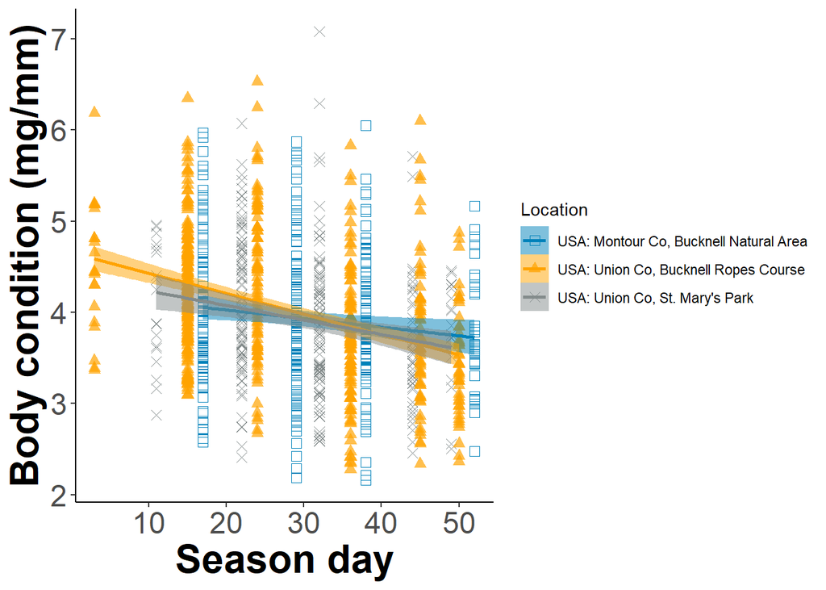

```r
#png(file="Figure2C_PhysCondition.png", width = 3200, height = 1600, res=300)

ggplot(Adult_Final, aes(x=SeasonDay, y=BodyCondition*1000,shape=Location, color=Location,alpha=Location)) +
  geom_point(aes(shape=Location, color=Location), size=2.5)+  scale_shape_manual(values=c(0, 17, 4))+
  scale_color_manual(values=c("#0082BA","#FFA300","#838B8B"))+
  scale_alpha_manual(values=c(1,.7,1))+
  theme(legend.position="top")+ theme(plot.margin = unit(c(1, 2, 1, 2), "inches"))+
 geom_smooth(se = TRUE, method=lm, aes(fill=Location, ), alpha = .5, size = 0,lwd=1) + theme_bw()+ theme_classic() +
  xlab("Season day") + ylab("Body condition (mg/mm)") + scale_fill_manual(values=c("#0082BA","#FFA300","#838B8B"))+
theme(axis.title.x = element_text(size=24, face="bold"),
axis.title.y = element_text(size=24, face="bold")) + theme(axis.text = element_text(size = 18))
```

```r
#dev.off()
```

#### Other visualizations

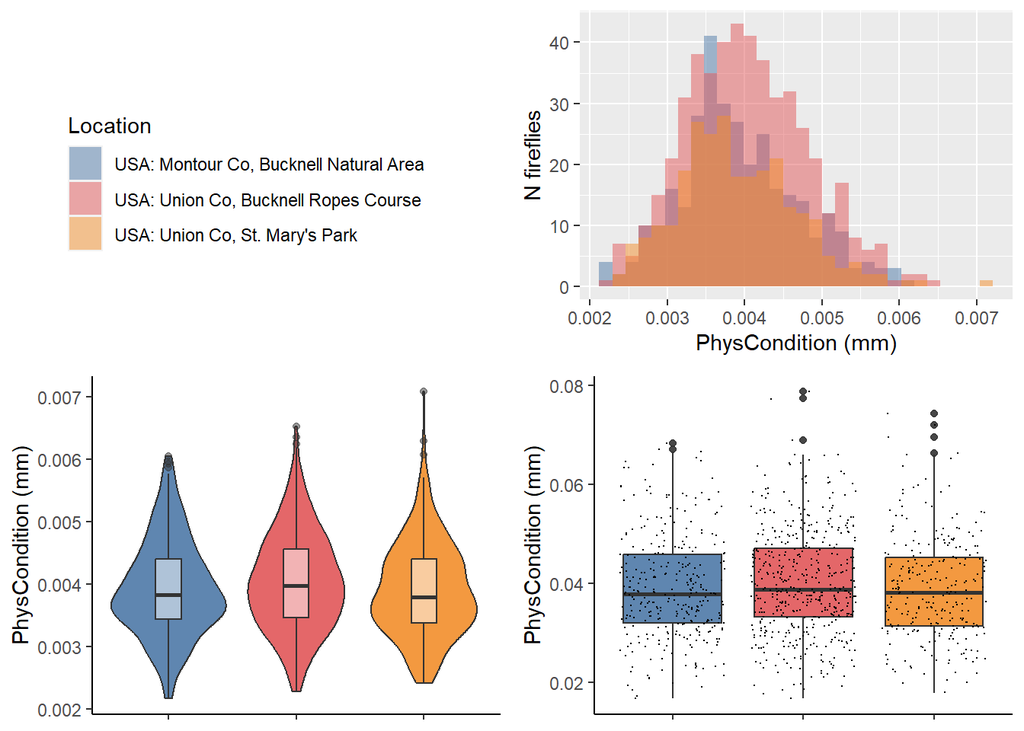

```r
#generate labels for sites that include sample size
site_labels = c(paste("BNA", " (n = ", t$N[1], ")", sep=""),
                paste0("FDBCC", " (n = ", t$N[2], ")"),
                paste0("StM",  " (n = ", t$N[3], ")"))

#generate text placeholder
a <- ggplot(Adult_Final, aes(x=BodyCondition, fill=Location,)) +
  geom_histogram(alpha= 0.5, position="identity") +
  scale_fill_manual(name = "Location",
                    #labels = site_labels,
                    values = site_colors)

legend.a <- cowplot::get_legend(a)

#generate histogram
b <- ggplot(Adult_Final, aes(x=BodyCondition, fill=Location)) +
  geom_histogram(alpha= 0.5, position="identity") +
  xlab("PhysCondition (mm)") +
  ylab("N fireflies") +
  theme(plot.title = element_text(hjust = 0.5), legend.position = "none") +
  scale_fill_manual(name = "Location", labels = site_labels, values = site_colors)+
  scale_fill_manual(name = "Location", labels = c("BNA", "FDBCC", "StM"), values = c("#4E79A7", "#E15759", "#F28E2B"))

#generate violin plot
c <- ggplot(Adult_Final, aes(x=Location, y=BodyCondition, fill=Location,)) +
  geom_violin(alpha = 0.9) +
  theme_classic() +
  ylab("PhysCondition (mm)") +
  theme(plot.title = element_text(hjust = 0.5), legend.position = "none", axis.text.x=element_blank(), axis.title.x=element_blank()) +
  geom_boxplot(width=0.2, alpha= 0.5, fill = "white") +
  scale_fill_manual(values = site_colors) +
  scale_fill_manual(name = "Location", labels = c("BNA", "FDBCC", "StM"), values = c("#4E79A7", "#E15759", "#F28E2B"))

#generate boxplot
d <- ggplot(Adult_Final, aes(x=Location, y=Mass, fill=Location,)) +
  geom_boxplot(alpha = 0.9) +
  geom_jitter(size = 0.1)+
  theme_classic() +
  ylab("PhysCondition (mm)") +
  theme(plot.title = element_text(hjust = 0.5), legend.position = "none", axis.text.x=element_blank(), axis.title.x=element_blank()) +
  scale_fill_manual(values = site_colors) +
  scale_fill_manual(name = "Location", labels = c("BNA", "FDBCC", "StM"), values = c("#4E79A7", "#E15759", "#F28E2B"))

grid.arrange(legend.a,b,c,d, nrow=2)
```

#### Calculate confidence intervals

- Calculated the confidence intervals for both the first day of collection and at day 15 for each location.
- Also calculated the confidence intervals for the change seen over 10 days for each location

```r
# beta.hats
b.h <- coef(lmBodyC)

# residual degrees of freedom:
d.f <- lmBodyC$df.residual

# variance covariance matrix of beta.hats
vc <- as.matrix(vcov(lmBodyC))

results.table <- matrix(NA, nr=3, ncol=10)
colnames(results.table) <- c("Day of First col", "Init Body Cond", "Low 95% CI: Init BC", "Up 95% CI: Init BC",
                             "Body Cond Day 15", "Low CI: Day 15", "Up CI: Day 15",
                             "10 Day change", "Low CI: 10 Day change", "Up CI: 10 Day change")
rownames(results.table) <- c("St. Mary's", "BNA", "FDBCC")

day.first.col <- c(11, 17, 3)
results.table[1:3, 1] <- day.first.col

# Initial Body condition (on day of first collection), 95% CI
## St. Mary's
val <- c(1, day.first.col[1], 0, 0, 0, 0)
results.table[1,2] <- sum(b.h*val)
# 95% CI
results.table[1,3:4] <- sum(b.h*val) + c(-1,1)*qt(0.975, d.f)*sqrt(sum(val%*%t(val) * vc))

## BNA
val <- c(1, day.first.col[2], 1, 0, day.first.col[2], 0)
results.table[2,2] <- sum(b.h*val)
# 95% CI
results.table[2,3:4] <- sum(b.h*val) + c(-1,1)*qt(0.975, d.f)*sqrt(sum(val%*%t(val) * vc))

## FDBCC
val <- c(1, day.first.col[3], 0, 1, 0, day.first.col[3])
results.table[3,2] <- sum(b.h*val)
# 95% CI
results.table[3,3:4] <- sum(b.h*val) + c(-1,1)*qt(0.975, d.f)*sqrt(sum(val%*%t(val) * vc))


# Body condition on Day 15, 95% CI

d <- 15  # using variable d instead of hard coding 15

## St. Mary's
val <- c(1, d, 0, 0, 0, 0)
results.table[1,5] <- sum(b.h*val)
# 95% CI
results.table[1,6:7] <- sum(b.h*val) + c(-1,1)*qt(0.975, d.f)*sqrt(sum(val%*%t(val) * vc))

## BNA
val <- c(1, d, 1, 0, d, 0)
results.table[2,5] <- sum(b.h*val)
# 95% CI
results.table[2,6:7] <- sum(b.h*val) + c(-1,1)*qt(0.975, d.f)*sqrt(sum(val%*%t(val) * vc))

## FDBCC
val <- c(1, d, 0, 1, 0, d)
results.table[3,5] <- sum(b.h*val)
# 95% CI
results.table[3,6:7] <- sum(b.h*val) + c(-1,1)*qt(0.975, d.f)*sqrt(sum(val%*%t(val) * vc))


# Change in body condition over 10 days, CI

delta.d <- 10 # using variable isntead of hard coding 10
## St. Mary's

val <- c(0, delta.d, 0, 0, 0, 0)
results.table[1,8] <- sum(b.h*val)
# 95% CI
results.table[1,9:10] <- sum(b.h*val) + c(-1,1)*qt(0.975, d.f)*sqrt(sum(val%*%t(val) * vc))


## BNA
val <- c(0, delta.d, 0, 0, delta.d, 0)
results.table[2,8] <- sum(b.h*val)
# 95% CI
results.table[2,9:10] <- sum(b.h*val) + c(-1,1)*qt(0.975, d.f)*sqrt(sum(val%*%t(val) * vc))

## FDBCC
val <- c(0, delta.d, 0, 0, 0, delta.d)
results.table[3,8] <- sum(b.h*val)
# 95% CI
results.table[3,9:10] <- sum(b.h*val) + c(-1,1)*qt(0.975, d.f)*sqrt(sum(val%*%t(val) * vc))

round(results.table, 2)
```

```
##            Day of First col Init Body Cond Low 95% CI: Init BC
## St. Mary's               11           4.25                4.16
## BNA                      17           4.06                3.93
## FDBCC                     3           4.59                4.45
##            Up 95% CI: Init BC Body Cond Day 15 Low CI: Day 15 Up CI: Day 15
## St. Mary's               4.34             4.18           4.11          4.26
## BNA                      4.18             4.07           3.93          4.22
## FDBCC                    4.72             4.32           4.23          4.41
##            10 Day change Low CI: 10 Day change Up CI: 10 Day change
## St. Mary's         -0.16                 -0.20                -0.12
## BNA                -0.09                 -0.17                -0.02
## FDBCC              -0.22                 -0.27                -0.18
```